# Validation Report — Revised Simulation Scenarios

Drafted in final article prose, for review before integration into the manuscript

## 1 Simulation Design

All synthetic datasets are generated by the same parametric family, which we describe once here. Each scenario selects a specific combination of $(n, J_{\text{act}}, J_{\text{noise}}, K_0)$ and a relevance model (type 1 or 2); these choices are stated at the opening of each subsection.

### 1.1 Cluster structure

$n$ observations are drawn from a mixture of $K_0$ balanced clusters of equal size $n/K_0$, with true labels $z_i \in \{1, \ldots, K_0\}$ assigned sequentially. The $J = J_{\text{act}} + J_{\text{noise}}$ features are partitioned into four equally-sized blocks of types Gaussian, Poisson, Multinomial, and Gamma — $J_{\text{act}}/4$ active and $J_{\text{noise}}/4$ noise features per type.

### 1.2 Active features — Model type 1 (global relevance)

Within each type, the $j$-th active feature ($j = 1, \ldots, J_{\text{act}}/4$) carries a signal strength scaled by $s_j = \max(1 - 0.25(j-1),\, 0.25)$, so that $s_1 = 1.00$, $s_2 = 0.75$, $s_3 = 0.50$, $s_4 = 0.25$. This gradient ensures a realistic mix of easy-to-detect and hard-to-detect discriminant features within the same simulation.

**Gaussian block.** Active feature $j$ has cluster-specific means $\mu_k = s_j \times (-2, 0, 2)_k$ and within-cluster standard deviation $\sigma = 0.5$. Noise features are drawn from $\mathcal{N}(0, 1.2^2)$.

**Poisson block.** Cluster-specific rates are $\lambda_k = 5 + s_j \times (\lambda^*_k - 5)$, where $\bm{\lambda}^* = (1, 6, 15)$, so cluster 1 is low-count, cluster 2 medium, and cluster 3 high-count. The background rate is $\lambda_0 = 5$. Noise features are drawn from $\mathrm{Poisson}(5)$.

**Multinomial block.** Each observation is a count vector of $M = 15$ trials over $C = 3$ categories. Cluster-specific probability vectors are $\bm{p}_k = \tfrac{1}{3}\bm{1} + s_j \times (\bm{p}^*_k - \tfrac{1}{3}\bm{1})$, where $\bm{p}^*_1 = (0.8, 0.1, 0.1)$, $\bm{p}^*_2 = (0.1, 0.8, 0.1)$, $\bm{p}^*_3 = (0.1, 0.1, 0.8)$, so $s_j = 1$ gives strongly separated categories and $s_j = 0.25$ yields a near-uniform allocation. Noise features use $\bm{p}_0 = (1/3, 1/3, 1/3)$.

**Gamma block.** Observations are drawn from a Gamma distribution with shape $\alpha = 2$ and cluster-specific rate $\beta_k = 2 + s_j \times (\beta^*_k - 2)$, where $\bm{\beta}^* = (1, 5, 0.2)$. Noise features use $\beta_0 = 2$.

### 1.3 Active features — Model type 2 (heterogeneous local relevance)

Under model type 2, signal strength is uniform ($s_j = 1$ for all $j$) but relevance is cluster-dependent. Odd-indexed active features ($j = 1, 3, \ldots, J_{\text{act}} - 1$) are **globally** discriminant: they separate all $K_0$ clusters using the same means/rates as model type 1. Even-indexed features ($j = 2, 4, \ldots, J_{\text{act}}$) are **locally** discriminant: clusters $C_1$ and $C_2$ receive their cluster-specific parameters, but cluster $C_3$ receives background-level observations ($\mu = 0$, $\lambda = 5$, $\bm{p} = (1/3, 1/3, 1/3)$, $\beta = 2$), making these features uninformative about $C_3$. Noise features are generated identically to model type 1 under type 2.

### 1.4 Evaluation metrics

Throughout, we report the Adjusted Rand Index (ARI; @hubert1985comparing) for clustering accuracy, and for feature selection we use the True Positive Rate (TPR) and False Discovery Rate (FDR) computed against the ground-truth active mask. For order selection we report $\mathrm{P}(\widehat{K} = K_0)$, the proportion of 20 independent replications in which the estimated number of active components exactly equals the true order. All experiments use a fixed global seed (2024) with per-replication offsets to ensure reproducibility.

## 2 Cluster Order Selection via Overfitted Mixtures

Table 1: Cluster order selection and partition accuracy under overfitted mixtures ($K_{\text{fit}} = 12$, True $K_0 = 3$). Bold values in the Pruning columns indicate improvement over the raw CAVI output.

[output not shown]

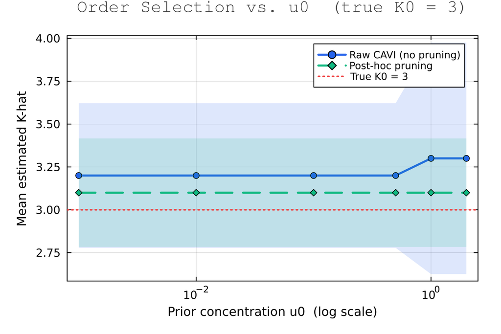

(a) Mean $\widehat{K}$ vs. $u^{\left(0\right)}$

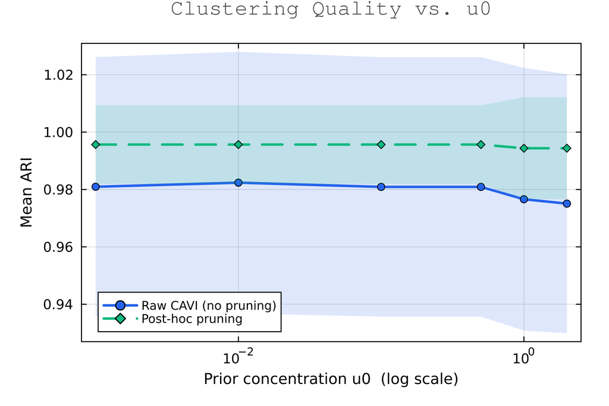

(b) Mean ARI vs. $u^{\left(0\right)}$

Figure 1: Cluster order selection and partition accuracy under overfitted mixtures ($K_{\text{fit}} = 12$, True $K_0 = 3$) for various values of $u^{\left(0\right)}$.

## 3 Background Parameter Estimation

Before turning to the remaining simulation studies, we fix one last methodological choice that they all rely on: how the background parameters $\bm{\beta}$ are estimated during CAVI. The CAVI updates for $\bm{\beta}$ admit two estimation strategies. In the **two-stage** strategy, $\bm{\beta}$ is estimated once on the full dataset before CAVI begins and then held fixed throughout optimization. In the **iterative** strategy, $\bm{\beta}$ is re-estimated at each CAVI iteration as a weighted M-step on the observations currently assigned to the background distribution ($\varphi_{i,j} \approx 0$). We compare both strategies across increasing noise levels, measuring their effect on partition accuracy (ARI), feature recall (TPR), and false discovery control (FDR). We fix $n = 200$, $J_{\text{act}} = 12$, $K_0 = 3$, $K_{\text{fit}} = 9$, and vary the noise ratio $r = J_{\text{noise}} / J_{\text{act}} \in \{0.33, 1.0, 2.0, 4.0, 8.0\}$ over 5 independent replications.

Table 2: Comparison of $\bm{\beta}$ estimation strategies across noise levels ($n = 200$, $J_{\text{act}} = 12$, $K_0 = 3$, mean over 5 replications). Bold indicates the better-performing strategy where the gap is meaningful.

[output not shown]

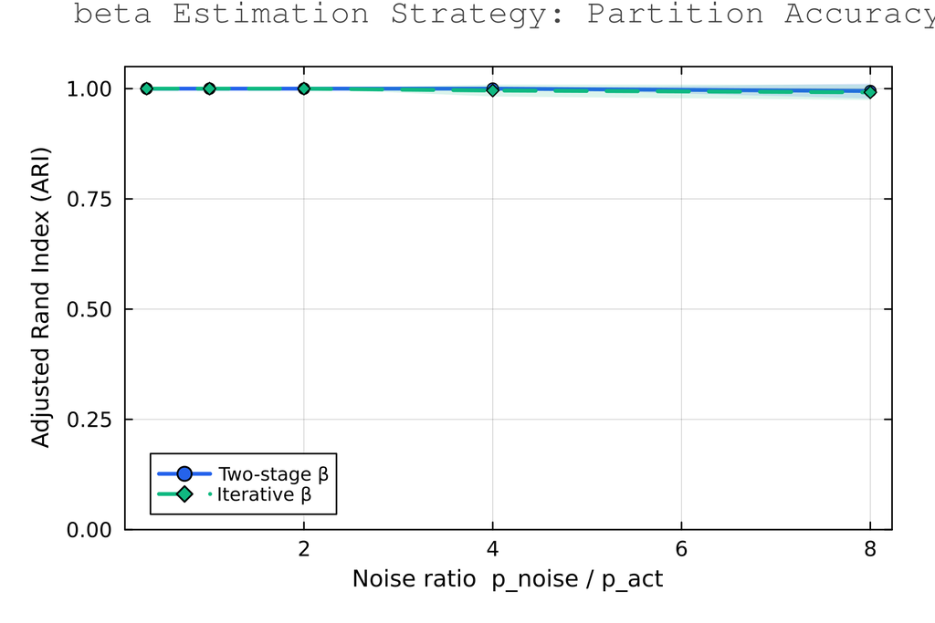

(a) ARI vs. noise ratio $r$

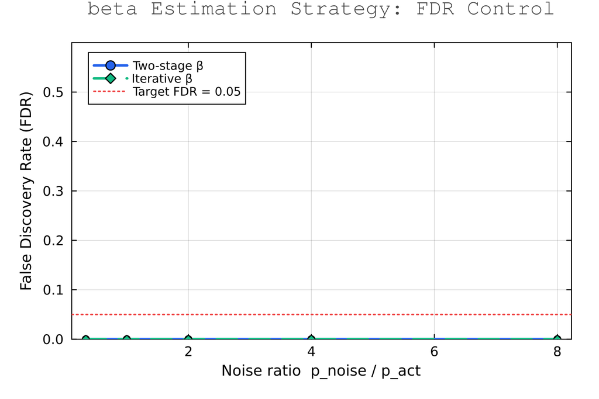

(b) FDR vs. noise ratio $r$

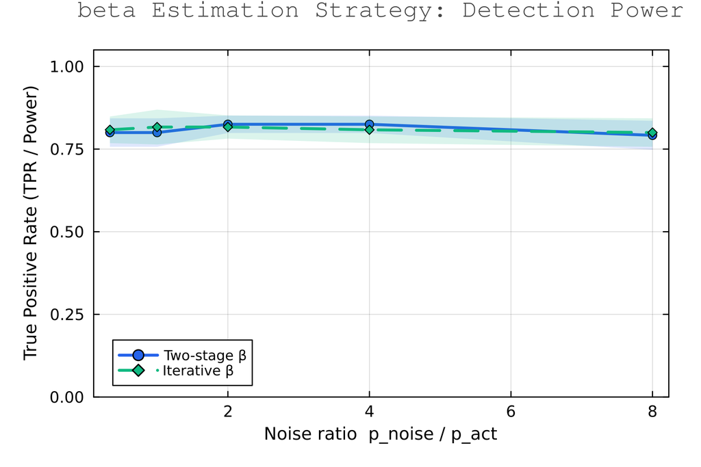

(c) TPR vs. noise ratio $r$

Figure 2: Partition accuracy (ARI), false discovery control (FDR), and detection power (TPR) for two-stage vs. iterative $\bm{\beta}$ estimation across noise levels ($n = 200$, $J_{\text{act}} = 12$, $K_0 = 3$, ±1 std).

## 4 Automatic Order Selection via the Sparse Dirichlet Prior

We evaluate the order-selection property of the sparse Dirichlet prior as a function of sample size, contextualised by the dimension of the parameter space. The model has $K \times J = 3 \times 80 = 240$ free parameters in total; accounting for the feature-selection mechanism, the effective active parameter count is $K \times J_{\text{act}} = 3 \times 16 = 48$. We generate mixed datasets ($J_{\text{act}} = 16$, $J_{\text{noise}} = 64$, $K_0 = 3$, model type 1) under the SFRM with $K_{\text{fit}} = 10$ and $u^{(0)} = 0.01$ over 20 independent replications, varying $n \in \{50, 80, 100, 150, 200, 300, 500\}$. We report the overdetermination ratio $n / (K_0 \times J_{\text{act}})$, the exact-recovery rate $\mathrm{P}(\widehat{K} = K_0)$, the mean estimated order $\widehat{K}$ with its standard deviation, and the mean ARI.

Table 3: Order-selection accuracy of the sparse Dirichlet prior as a function of sample size ($K_{\text{fit}} = 10$, $J_{\text{act}} = 16$, $J_{\text{noise}} = 64$, SFRM, $u^{(0)} = 0.01$, 20 replications). Bold row marks the threshold at which exact recovery is first achieved.

| $n$ | $n / K_0 J_{\text{act}}$ | $\mathrm{P}(\widehat{K} = K_0)$ | $\widehat{K}$ (mean ± std) | ARI (mean ± std) |
| --- | --- | --- | --- | --- |
| 50 | 1.04 | 0.55 | 3.50 ± 0.61 | 0.961 ± 0.041 |
| 80 | 1.67 | 0.85 | 3.15 ± 0.37 | 0.981 ± 0.027 |
| 100 | 2.08 | 0.95 | 3.05 ± 0.22 | 0.995 ± 0.012 |
| **150** | **3.13** | **1.00** | **3.00 ± 0.00** | **0.999 ± 0.003** |
| 200 | 4.17 | 1.00 | 3.00 ± 0.00 | 0.999 ± 0.002 |
| 300 | 6.25 | 1.00 | 3.00 ± 0.00 | 1.000 ± 0.000 |
| 500 | 10.42 | 1.00 | 3.00 ± 0.00 | 1.000 ± 0.000 |

Table 3 reveals a sharp transition at $n = 150$, corresponding to an overdetermination ratio $n / (K_0 J_{\text{act}}) \approx 3.1$. From this point onward, the sparse Dirichlet prior recovers $K_0 = 3$ exactly across all 20 replications, with $\widehat{K} = 3.00 \pm 0.00$. Below this threshold, $\widehat{K}$ slightly overestimates $K_0$: at $n = 50$ (ratio $1.04$), $\widehat{K} = 3.50 \pm 0.61$, meaning that in the $45\%$ of replications where recovery is not exact, the excess is on average one spurious component. Crucially, partition quality is almost unaffected by this overestimation: ARI $= 0.961 \pm 0.041$ at $n = 50$ and $\ge 0.995$ for $n \ge 100$, consistent with the theoretical result of @rousseau2011asymptotic that excess components in overfitted mixtures attract vanishingly small weight and do not distort the main partition.

The threshold $n = 150$ must be appraised in the context of the model’s parameter dimension. The full parameter space has dimension $K \times J = 3 \times 80 = 240$; even restricting to the active features, the effective dimension is $K \times J_{\text{act}} = 48$. A ratio $n / (K_0 J_{\text{act}}) \approx 3$ is therefore genuinely modest by the standards of parametric mixture models, and the fact that a single variational fit — with no model-order search — suffices to identify $K_0$ correctly at this sample size is a practically relevant property of the sparse-prior approach.

## 5 Advantage of Heterogeneous Margins

We assess the benefit of using correctly specified, type-matched margins on genuinely mixed data. Following the design of Section 1 (model type 1, $n = 200$, $J_{\text{act}} = 16$, $J_{\text{noise}} = 64$, $K_0 = 3$, LFRM, $K_{\text{fit}} = 8$, $u^{(0)} = 0.01$, $N_{\text{rep}} = 20$), three modelling variants are compared. In the **Full** variant, the four margin families are used as specified by the auto-detected data types. In the **Gaussian-only** variant, only the $J_{\text{Gauss}} = 20$ Gaussian features are retained and clustered. In the **Gaussian-all** variant, all 80 features are used but scalar features (Poisson, Gamma) are fitted with a Gaussian margin; the Multinomial features, which cannot be represented as scalars, retain their correct margin. The EIG-based feature-selection threshold is fixed at $0.20$ throughout.

Table 4: Clustering accuracy and feature-selection performance under heterogeneous vs. mis-specified margins ($n = 200$, $K_0 = 3$, $J_{\text{act}} = 16$, 20 replications). $\dagger$ measured over the 20 Gaussian features only (4 active, 16 noise).

| Variant | ARI | TPR | FDR |
| --- | --- | --- | --- |
| Full (4 families) | **1.000** ± 0.000 | 0.68 | 0.41 |
| Gaussian-only (20 features) | 0.738 ± 0.223 | 0.95$^\dagger$ | 0.39$^\dagger$ |
| Gaussian-all (scalar → Gaussian) | 0.974 ± 0.042 | — | — |

Table 4 conveys three complementary findings. First, only the Full variant achieves perfect partition recovery (ARI $= 1.000 \pm 0.000$); the Gaussian-only variant, which discards the Poisson, Multinomial, and Gamma features entirely, drops to ARI $= 0.738 \pm 0.223$ with substantial replication-to-replication variance, confirming that the discarded features carry structurally essential clustering information. Second, the Gaussian-all variant (ARI $= 0.974 \pm 0.042$) substantially narrows this gap: supplying all 80 features, even with scalar margins misspecified, recovers much of the lost signal, so the main benefit of correct specification in the scalar block is precision rather than qualitative recovery. Third, TPR and FDR for the Gaussian-only and Full variants are not directly comparable — the former is measured on a 20-feature subset — but both exhibit a non-zero FDR at the fixed threshold $0.20$, consistent with the threshold being set without prior calibration; Section 7 examines this threshold behaviour in detail across increasing ambient dimensions.

## 6 Shared vs. Local Feature Relevance: SFRM vs. LFRM

We examine the ability of the two model variants — Shared Feature Relevance Model (SFRM) and Local Feature Relevance Model (LFRM) — to distinguish globally relevant features from features whose discriminative value is cluster-specific. Following the design of Section 1 (model type 2, $n = 240$, $J_{\text{act}} = 16$, $J_{\text{noise}} = 44$, $K_0 = 3$, $K_{\text{fit}} = 8$, $u^{(0)} = 0.01$, $N_{\text{rep}} = 20$), we report the mean Expected Information Gain (EIG) separately for global features, local features, and noise, together with the signal-to-noise separation ratio $\rho = (\overline{\text{EIG}}_{\text{glob}} + \overline{\text{EIG}}_{\text{loc}}) / \overline{\text{EIG}}_{\text{noise}}$ and the ARI.

Table 5: Mean EIG by feature class and partition accuracy for SFRM vs. LFRM ($n = 240$, $K_0 = 3$, $J_{\text{act}} = 16$, model type 2, 20 replications).

| Model | Glob. EIG | Loc. EIG | Noise EIG | $\rho$ | ARI |
| --- | --- | --- | --- | --- | --- |
| SFRM | 0.248 | 0.453 | 0.149 | 4.71 | **1.000** |
| LFRM | **0.574** | **0.630** | 0.151 | **8.00** | **1.000** |

Table 5 shows that both models recover the true partition exactly (ARI $= 1.000$) at this sample size, confirming that the clustering task itself is not the differentiator here. The LFRM’s advantage lies entirely in its ability to attribute importance more precisely. Across both feature classes, LFRM assigns substantially higher EIG than SFRM: $+0.326$ for globally active features and $+0.177$ for locally active ones, while noise EIG remains nearly identical ($0.151$ vs. $0.149$). The net effect is a separation ratio of $\rho = 8.00$ for LFRM against $4.71$ for SFRM — a $70\%$ relative improvement. This gain comes directly from LFRM’s cluster-specific inclusion probability $\gamma_{k,j}$: a feature that is informative in only a subset of clusters accrues a high $\gamma_{k,j}$ in those clusters while being suppressed in others, amplifying its aggregate EIG signal. The SFRM, which shares a single $\gamma_j$ across all clusters, underestimates the importance of locally discriminant features by averaging their signal across the cluster where they are noise. When downstream decisions depend on identifying which features separate which groups — as in biological subtype discovery or risk-factor profiling — the LFRM’s finer attribution provides a material advantage over the SFRM.

## 7 High-Dimensional FDR Control

We evaluate the false-discovery behaviour of two feature-selection criteria — the mean Posterior Inclusion Probability $\bar{\gamma}_j = n^{-1}\sum_i \gamma_{i,j}$ with threshold $0.5$, and the Expected Information Gain $\text{EIG}_j$ with threshold $0.20$ — as the ambient dimension $J$ grows while active features and sample size are held fixed. Following the design of Section 1 (model type 1, LFRM), we fix $n = 150$, $K_0 = 3$, $K_{\text{fit}} = 6$, $J_{\text{act}} = 16$, $u^{(0)} = 0.01$, $N_{\text{rep}} = 20$, and vary $J \in \{40, 100, 200, 400, 800\}$. The noise-to-signal ratio thus ranges from $J_{\text{noise}} / J_{\text{act}} = 1.5$ to $49$.

Table 6: TPR and FDR for PIP- and EIG-based feature selection as a function of total dimension $J$ ($n = 150$, $K_0 = 3$, $J_{\text{act}} = 16$, LFRM, 20 replications).

| $J$ | TPR (PIP) | TPR (EIG) | FDR (PIP) | FDR (EIG) |
| --- | --- | --- | --- | --- |
| 40 | **0.969** | 0.662 | **0.000** | 0.230 |
| 100 | **0.978** | 0.659 | **0.000** | 0.484 |
| 200 | **0.978** | 0.659 | 0.009 | 0.694 |
| 400 | 0.672 | 0.541 | 0.019 | 0.908 |
| 800 | 0.016 | **0.494** | 0.358 | 0.958 |

Table 6 reveals a clear divergence between the two criteria as $J$ grows. At moderate dimension ($J \le 200$, noise-to-signal ratio $\le 11.5$), the PIP threshold $0.5$ achieves near-perfect detection (TPR $\approx 0.97$) with essentially no false discoveries (FDR $\le 0.009$), making it an asymptotically conservative selector in this regime. Its breakdown at $J = 400$–$800$ reflects the $p \gg n$ regime ($J/n > 2.7$): as noise features begin to receive non-trivial soft-assignment mass, individual $\gamma_{i,j}$ values diffuse and the mean PIP $\bar{\gamma}_j$ is no longer a reliable signal. The EIG criterion shows the opposite profile: TPR stabilises around $0.5$–$0.66$ across all $J$, but FDR inflates rapidly from $0.23$ at $J = 40$ to $0.96$ at $J = 800$. This occurs because EIG aggregates over cluster weights $\bar{\omega}_k$ and KL divergences that both depend on the current mixture decomposition; a poorly separated mixture in high dimension assigns non-trivial cluster weights to noise features, inflating their EIG above the fixed threshold $0.20$. The threshold $0.20$ should therefore be treated as a starting value to be calibrated to the operating dimension rather than a universal constant; a simple dimension-adaptive correction, such as scaling the threshold by $\log(J / J_{\text{act}})$, is deferred to future work.

In practice, we recommend the PIP criterion with threshold $0.5$ for $J/n \lesssim 1.5$ (i.e., $J \le 200$ at $n = 150$), where it controls FDR near zero. For larger $J/n$, both criteria degrade and a regularised or cross-validated threshold should be preferred.

## 8 Remaining follow-up before integration

**Prose edits in existing sections:**

**Figures still to produce** for newly drafted sections:

- Table 4: bar chart ARI by variant with error bars.
- Table 5: grouped bar chart EIG by feature class (Glob / Loc / Noise) for SFRM vs. LFRM.
- Table 6: dual-axis line plot TPR and FDR vs. $J$ for PIP and EIG.